# Extending the feature set: automated selection and race-level interactions on UK All-Weather Flat handicaps

Paper 2a in a series on UK All-Weather racing outcomes

Author

Patrick Gillen

Published

June 21, 2026

Abstract

Paper 1 replicated Owen’s (2019) conditional-logit win model on UK All-Weather Flat handicaps and found it trailing the betting market across the threshold range (-28.2% ROI). We enrich the win model in two ways on the same data: an extended feature set, screened by a univariate McFadden pseudo-R²; and race-level features — distance and course — entered through the mixed discrete-choice formulation as interactions with horse-level features. The official rating is the strongest new predictor, and a course-specific draw bias for Kempton and Southwell emerges through the interaction, invisible to a pooled draw term. Evaluated on win metrics (the P1/P2 scoring rules and an industry starting-price (SP) betting backtest), the extended win model with the draw×course interaction moves ROI from -28.2% in paper 1 to -25.4% in the final model. The direction is consistent across every contrast we test, but a paired race-level bootstrap of the ROI difference cannot distinguish either gain from zero, though still well behind the market. The companion paper 2b holds this feature set fixed and changes the objective from win prediction to ranking.

*Revised 2026-07-03.*[^1]

# 1 Introduction

Paper 1 replicated the conditional-logit win model of Owen (2019) — one of a line of discrete-choice race models reaching back to Bolton and Chapman (1986) — on UK All-Weather (AW) Flat handicaps and found that the model’s win predictions were less accurate than the betting market’s across the full threshold range, returning -28.2% on the backtest. Its probabilities were sound on average — when it said 20%, horses won about a fifth of the time — but it was not separating likely winners from likely losers sharply enough to compete with an industry starting price that already aggregates weight, draw, going, jockey, recent form and informed money. This paper keeps the win objective and the data fixed, and asks how far a richer feature set can improve on that.

We make two contributions. First, an **extended feature set**, evaluated with an automated univariate screen — a standalone conditional logit per candidate, ranked by a univariate McFadden pseudo-$R^2$ against the equal-probability null, a screening approach used by Juola (2018). Second, **race-level interactions** through the mixed discrete-choice formulation: distance and course are constant within a race and so cancel in the softmax, but their products with horse-level features vary across runners and can enter the model — and this recovers a course-specific draw bias invisible to a win model with a single pooled draw term. Data scope, race selection and the train/test split are unchanged from paper 1.

The win-model ROI moves from -28.2% in paper 1 to -25.4% in the final model — an improvement that is directionally consistent but, on a paired race-level bootstrap of the ROI difference, not statistically distinguishable from zero; the market remains more accurate. The official rating (`or_relative`) is the strongest new predictor and the largest single contributor to the backtest gain, with the draw × course interaction adding a smaller further improvement. The companion paper 2b keeps this feature set fixed and changes the objective — from predicting the win to predicting the finishing order — to ask whether the ranking likelihood extracts more from the same features.

# 2 Data and scope

## 2.1 Race selection and window

The data scope is unchanged from paper 1: UK All-Weather (AW) Flat handicaps in Classes 2–5, run at the four AW courses (Kempton, Lingfield, Southwell and Wolverhampton) between 2006-01-01 and 2015-10-14, with declared fields of 4–16 and exactly one winner per race. We refer the reader to paper 1 for the full selection criteria and their motivation (the `race_type` filter, the 2006 class-system cutoff, the cross-surface career history, and the dead-heat and non-runner handling), none of which we revisit here. The chronological 70/30 train/test split is also carried over verbatim: every race on or before 2012-12-30 is training, everything after is test, so no within-race information crosses the boundary.

Table 1: Race and runner counts by split, on the qualifying AW Class 2–5 handicap population.

| Split | Races | Runners |
| --- | --- | --- |
| Training (≤ 2012-12-30) | 5,209 | 47,893 |
| Test (> 2012-12-30) | 2,232 | 18,877 |

## 2.2 Feature set

Paper 2 works from a two-tier predictor set: the Owen baseline, re-estimated on the AW data, and a set of new candidates drawn from the racing literature and the All-Weather context. Table 2 lists them, grouped by tier and by whether each is a horse-level feature or a race-level feature entered through an interaction.

Table 2: Paper-2 feature set: Owen baseline (re-estimated on AW), new horse-level candidates, and race-level interactions.

| Group | Feature | Description | Type | Source |
| --- | --- | --- | --- | --- |
| Owen baseline | age_diff | Symmetric distance from peak age (3 on AW) | horse-level | Owen (2019) |
| Owen baseline | daysLTO (log) | Log days since last run | horse-level | Owen (2019) |
| Owen baseline | trainerSR / sireSR | Cumulative pre-race strike rate | horse-level | Owen (2019) |
| Owen baseline | position lags 1–3 | Prior finishing positions (zero-plus-slope encoding) | horse-level | Owen (2019) |
| Owen baseline | entire / gelding | Sex indicators | horse-level | Owen (2019) |
| Owen baseline | cheekpieces | Tack indicator | horse-level | Owen (2019) |
| New horse-level | jockeySR | Cumulative pre-race jockey strike rate | horse-level | Juola (2018) |
| New horse-level | or_relative | Official rating minus race-mean rating | horse-level | Betwise blog |
| New horse-level | or_missing | Indicator: official rating was NULL | horse-level | Betwise blog |
| New horse-level | rel_weight | Weight carried minus race-mean weight | horse-level | Benter (1994) |
| New horse-level | trainer_aw_premium | Trainer AW strike rate minus overall strike rate | horse-level | Juola (2018) |
| New horse-level | has_wins | Indicator: any prior career win | horse-level | Betwise blog |
| Race-level × horse | rel_weight × distance | Weight deviation interacted with race distance | race-level × horse-level | Benter (1994) |
| Race-level × horse | draw × course | Normalised draw interacted with course | race-level × horse-level | Betwise blog |

## 2.3 Data decisions

**Position encoding.** Paper 1 entered the three prior-finish lags as twelve factor coefficients. We adopt a more parsimonious *zero-plus-slope* encoding — six coefficients, two per lag (a zero indicator plus a single linear slope across placings 1–4) — which a likelihood-ratio test finds loses nothing against the full factor grid. The encoding and the test are set out in Section 3.

**Draw × course construction.** Normalised draw (`stall_normalised`) showed near-zero standalone signal in the univariate screen, but draw bias on AW is known to be track-specific. We enter it as four course-specific slopes in the mixed logit (Section 5), admitted as a block on a likelihood-ratio test and then reduced by the same per-term Wald rule used throughout: only the two courses whose draw slope is individually significant at $p < 0.05$ — Kempton and Southwell — are retained, while Lingfield (no detectable bias) and Wolverhampton (a weak, marginally non-significant tendency to favour lower draws) are dropped. The final model carries course-specific draw effects for Kempton and Southwell.

# 3 Feature evaluation

All exploratory analysis in this section uses the **training split only** (70/30 chronological, cutoff 2012-12-30). Win-rate summaries, tables, and plots are computed after filtering to `split == "train"`, so nothing here is informed by the held-out test races. (Paper 1 computed its exploratory summaries on the full joined tibble; that paper is complete and is not being revisited.)

## 3.1 Headline counts (training split)

Table 3: Training-split headline counts (70/30 chronological, cutoff 2012-12-30).

| Quantity | Value |
| --- | --- |
| Training races | 5,209 |
| Training runners | 47,893 |
| Date range | 2006-01-01 to 2012-12-30 |
| Field size (min / median / max) | 4 / 9 / 16 |
| Win rate | 10.88% |

With field sizes between 4 and 16 and exactly one winner per race, the headline win rate per runner-row follows directly from there being exactly one winner per race — it is the reciprocal of the average field size, not a signal about any feature.

## 3.2 Automated feature evaluation

We rank every candidate feature by a univariate screen. For each feature we fit a standalone no-intercept conditional logit (race = choice set) on the training races and score it by the McFadden pseudo-$R^2$,
$$R^2_{\text{McF}} = 1 - \frac{\log L_{\text{model}}}{\log L_{\text{null}}},$$
where $\log L_{\text{null}}$ assigns every runner the equal probability $1/\text{field size}$, following the screening approach of Juola (2018) (§4.3.6). Each feature’s score uses only the races where that feature has a value, so `n_races` differs by feature. The three prior-finish lags are screened together as one conceptual feature (`position_lags`).

Table 4: Univariate McFadden R² screen, all 19 candidate features, ranked. Training races only.

| Feature | McFadden R² | n races |
| --- | --- | --- |
| or_relative | 0.03510 | 3948 |
| position_lags | 0.03326 | 5209 |
| trainerSR | 0.01312 | 5186 |
| jockeySR | 0.01079 | 5121 |
| rel_weight | 0.00913 | 5209 |
| weight_delta_lbs | 0.00803 | 4782 |
| age_diff | 0.00586 | 5209 |
| entire | 0.00411 | 5209 |
| daysLTO | 0.00380 | 5207 |
| sireSR | 0.00377 | 5174 |
| trainer_aw_premium | 0.00255 | 5209 |
| has_wins | 0.00241 | 5209 |
| cheekpieces | 0.00082 | 5209 |
| sire_aw_premium | 0.00081 | 5209 |
| jockey_aw_premium | 0.00068 | 5209 |
| stall_normalised | 0.00034 | 5208 |
| gelding | 0.00020 | 5209 |
| first_time_aw | 0.00011 | 5209 |
| class_delta | 0.00004 | 4467 |

Two caveats temper the ranking. First, each score depends on the assumed functional form: a feature entered linearly may screen weakly yet carry signal under a better transformation (or as an interaction). Second, standalone univariate signal is not the same as marginal contribution — a feature can rank highly alone yet add little once correlated features are already in the model. The screen is a first-pass filter, not the final word; the conditional-logit fits in Section 4 are the proper multivariate test.

## 3.3 Feature drop decisions

We drop the weakest candidates before model fitting, on the evidence of the screen above.

**`weight_delta_lbs` (dropped).** Its NA mechanism is not missing-at-random: a missing value means the horse has *no prior run in the comparable-class era* (2006 onward) — almost always, simply no prior run — not that its weight was unchanged. Imputing 0 would assert “no change since last time” for a horse that has no last time — a substantively false statement. The univariate signal is weak (McFadden R² 0.008), and `rel_weight` already captures the within-race weight level without any NA problem. Dropped.

**Weak-signal features (dropped).** Each of the following has a univariate McFadden R² at or near zero and is dropped before model fitting:

- `class_delta` (McFadden R² 0.00004) — the handicapper already prices class moves into the allotted weight, so the residual signal is negligible.
- `sire_aw_premium` (0.0008) — no standalone All-Weather edge over the sire’s overall rate.
- `jockey_aw_premium` (0.0007) — likewise for jockeys.
- `stall_normalised` (0.0003) — draw effect is near-zero pooled across courses and distances (a candidate for a course interaction in a later paper, not a main effect here).
- `first_time_aw` (0.0001) — AW debut carries essentially no marginal win signal once form is accounted for.

**Deferred decisions.** `gelding`, `cheekpieces`, `has_wins`, and `trainer_aw_premium` are *not* dropped here. They enter the full conditional-logit model in Section 4 and are removed only if their coefficients fail the significance test ($p > 0.05$) in the reduced model — the same reduction rule paper 1 applied to Owen’s specification. These are deferred, not dropped outright, because the univariate screen can miss a feature that carries little signal on its own yet matters once other features are already in the model.

## 3.4 Position encoding: from factors to the zero-plus-slope encoding

The three prior-finish lags record a horse’s finishing position in its most recent, second-most-recent and third-most-recent runs. Each takes a value in $\{0, 1, 2, 3, 4\}$: $1$–$4$ for a top-four finish, and $0$ for “no qualifying recent finish” — either no prior run, or a finish worse than fourth.

Paper 1 entered each lag as a *factor*, spending one coefficient on each placing $1$–$4$ (with $0$ as the reference): four coefficients per lag, twelve in all. That is maximally flexible but not parsimonious. We test two cheaper encodings against it on the training races, position terms only. The **single-slope encoding** is the aggressive one — a single position score plus a lag-decay term, two coefficients for all three lags combined. The **zero-plus-slope encoding** is the middle ground: per lag it gives the $0$ category its own term and forces only placings $1$–$4$ onto a straight line, via a binary indicator `pos_lagN_zero` (is the value $0$?) and a numeric slope `pos_lagN_nonzero` (the placing $1$–$4$, else $0$) — two coefficients per lag, six in all. Table 5 shows how one lag’s value enters the linear predictor under the factor encoding and under the zero-plus-slope encoding.

Table 5: One prior-finish lag’s contribution to the linear predictor. The factor encoding gives every placing a free effect; the zero-plus-slope encoding separates the “no recent finish” category and constrains placings 1–4 to a straight line (three lags: twelve coefficients under the factor encoding, six under zero-plus-slope).

| Last finish | Factor encoding | Zero-plus-slope (adopted) |
| --- | --- | --- |
| 0 (no top-4) | reference | $\gamma_{\text{zero}}$ |
| 1st | $\beta_1$ | $\gamma_{\text{slope}}\times 1$ |
| 2nd | $\beta_2$ | $\gamma_{\text{slope}}\times 2$ |
| 3rd | $\beta_3$ | $\gamma_{\text{slope}}\times 3$ |
| 4th | $\beta_4$ | $\gamma_{\text{slope}}\times 4$ |
| **coefficients per lag** | **4** | **2** |

The single-slope encoding is decisively rejected against the factor grid (LR $=$ 600, df $=$ 10, $p < 0.001$): collapsing everything to one slope forces the $0$ category onto the same numeric scale as a win, which is substantively wrong. The zero-plus-slope encoding, by contrast, is **not** rejected (LR $=$ 4.88, df $=$ 6, $p =$ 0.56), and AIC prefers it to the twelve-coefficient grid by about 7 points. So once the $0$ category has its own term, placings $1$–$4$ are effectively linear, and six coefficients capture what twelve did. We adopt the zero-plus-slope encoding for every paper-2 fit; the empirical win-rate-by-position curves that motivate the linearity are plotted later in this section.

## 3.5 `or_relative` — coverage and imputation

`or_relative` (a runner’s official rating minus the race-mean official rating) is the strongest new feature in the screen, but it is also the one with a real coverage cost.

Table 6: Official-rating coverage on the training split.

| Quantity | Value |
| --- | --- |
| Runners with NULL official rating | 14.4% |
| Training races affected | 1,261 of 5,209 (24%) |

The missingness is **not at random**: a horse with no official rating is typically unexposed (too few qualifying runs to be rated) or returning from a long absence — a distinct population, not a random sample of the field. Dropping these runners complete-case would discard roughly a quarter of training races, and (because the gap is concentrated in the early part of the window) would skew the training period.

Our decision is therefore to **impute `or_relative` = 0** for unrated runners and add a binary companion **`or_missing`** (1 where the rating was NULL). The companion lets the model estimate the missing-OR group effect separately, rather than forcing those horses onto the zero point of the `or_relative` scale (which would otherwise read as “exactly average”). This recovers full coverage at no cost to race count, and is applied in the `runners_model_ready` target that every subsequent modelling step consumes.

## 3.6 Win-rate plots for retained features

The plots below follow paper 1’s visual style: empirical win rate per bin with per-bin standard errors, a dashed reference line at the overall (training) win rate, and the bin count above each bar. All are computed on the training split only. Dropped features are not plotted.

### 3.6.1 Official rating (relative) and its missingness indicator

The continuous `or_relative` curve is shown on rated runners only (`or_missing == 0`), so the binning reflects genuine rating spread rather than the imputed zeros; `or_missing` is then shown on its own.

Table 7: Win rate by relative official rating (rated runners).

| feature | feature_bin | n | n_wins | win_rate | se |
| --- | --- | --- | --- | --- | --- |
| or_relative | [-Inf,-20) | 191 | 7 | 0.0366 | 0.0136 |
| or_relative | [-20,-10) | 1405 | 60 | 0.0427 | 0.0054 |
| or_relative | [-10,-5) | 4777 | 276 | 0.0578 | 0.0034 |
| or_relative | [-5,-2) | 6656 | 524 | 0.0787 | 0.0033 |
| or_relative | [-2,2) | 12835 | 1279 | 0.0996 | 0.0026 |
| or_relative | [2,5) | 8726 | 1084 | 0.1242 | 0.0035 |
| or_relative | [5,10) | 5242 | 914 | 0.1744 | 0.0052 |
| or_relative | [10,20) | 1027 | 372 | 0.3622 | 0.0150 |
| or_relative | [20, Inf] | 119 | 24 | 0.2017 | 0.0368 |

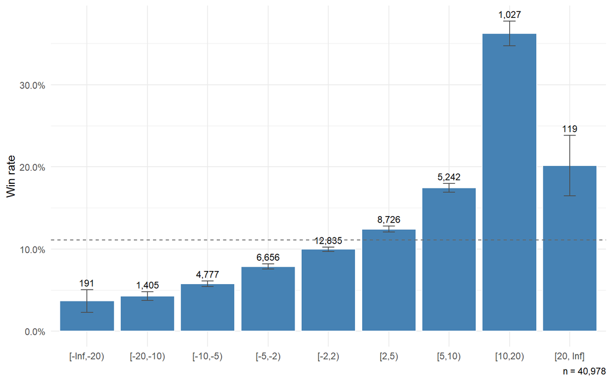

Figure 1: Win rate by relative official rating (rated training runners).

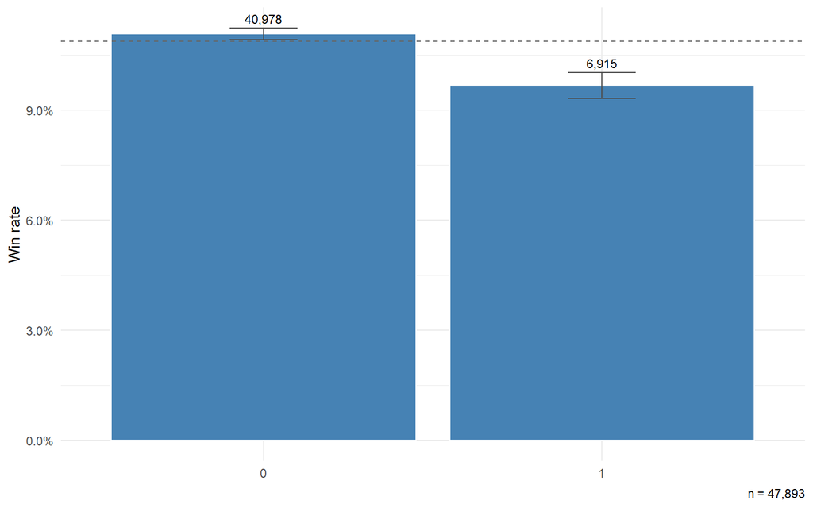

Figure 2: Win rate by or_missing (1 = no official rating).

### 3.6.2 Relative weight

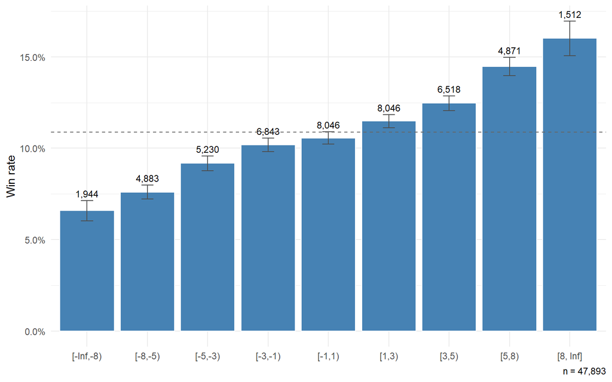

Figure 3: Win rate by relative weight (lb above/below the race mean).

### 3.6.3 Strike rates: jockey, trainer, sire

`jockeySR` is the new jockey analogue of Owen’s `trainerSR` / `sireSR`; all three are cumulative pre-race win rates, uncapped, binned with finer resolution at the low end where the mass sits.

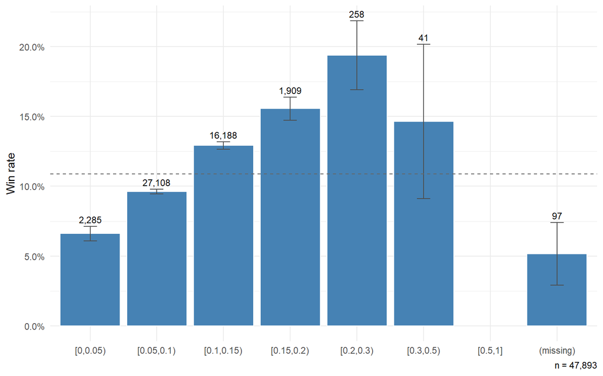

Figure 4: Win rate by jockey strike rate.

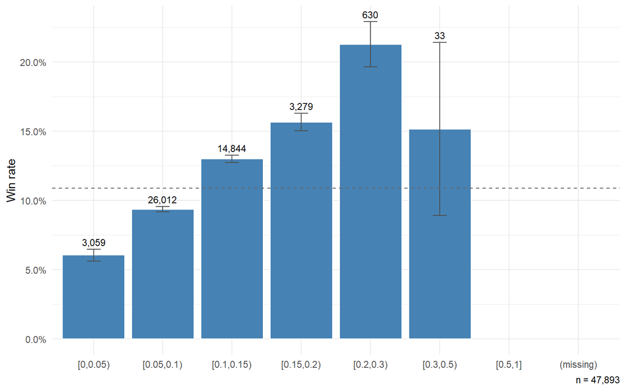

Figure 5: Win rate by trainer strike rate (AW training data).

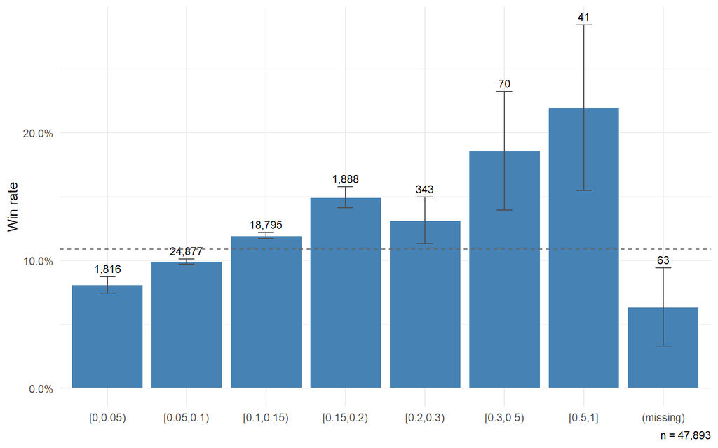

Figure 6: Win rate by sire strike rate (AW training data).

### 3.6.4 Trainer All-Weather premium

Carried into the full model; the drop decision is deferred to the reduced-model coefficient test.

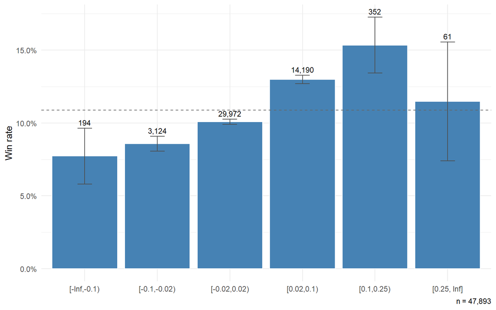

Figure 7: Win rate by trainer AW premium (AW rate minus overall rate).

### 3.6.5 Owen baseline features carried forward

`age_diff` (symmetric distance from age 3) and `daysLTO` (binned on log-spaced rest intervals) are replotted here on the AW training split.

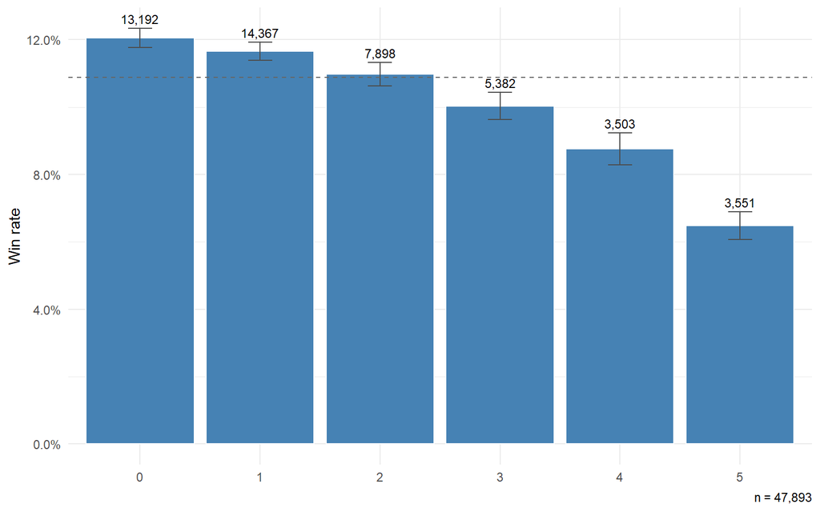

Figure 8: Win rate by age_diff = min(|age - 3|, 5).

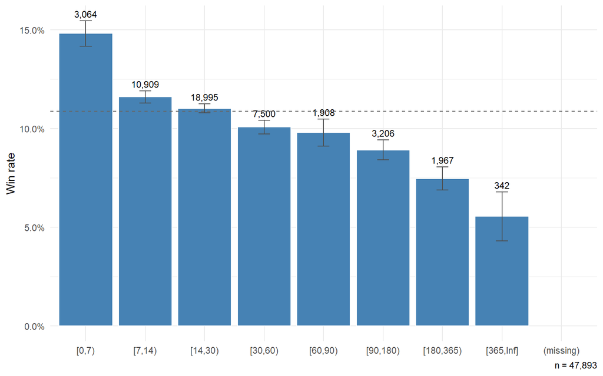

Figure 9: Win rate by days since last race, on log-spaced rest bins.

### 3.6.6 Binary sex / tack / form indicators

`entire`, `gelding`, and `cheekpieces` carry forward from Owen’s specification; `has_wins` (any prior career win) is a new binary candidate carried into the full model.

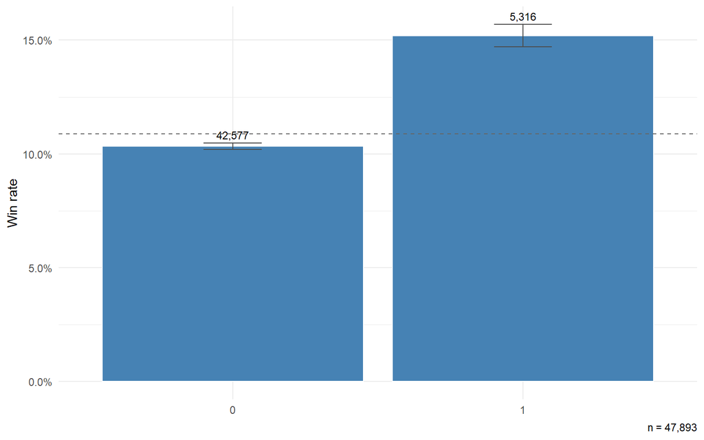

Figure 10: Win rate by entire

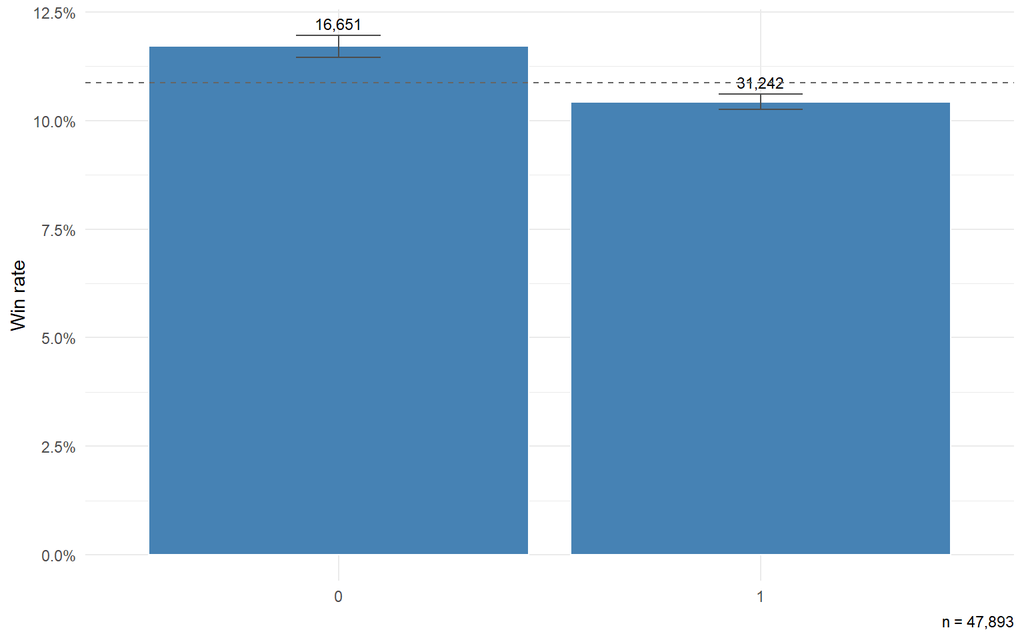

Figure 11: Win rate by gelding

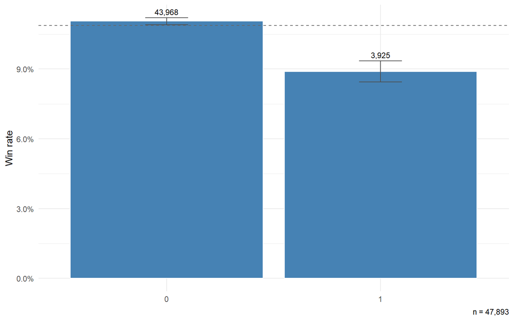

Figure 12: Win rate by cheekpieces

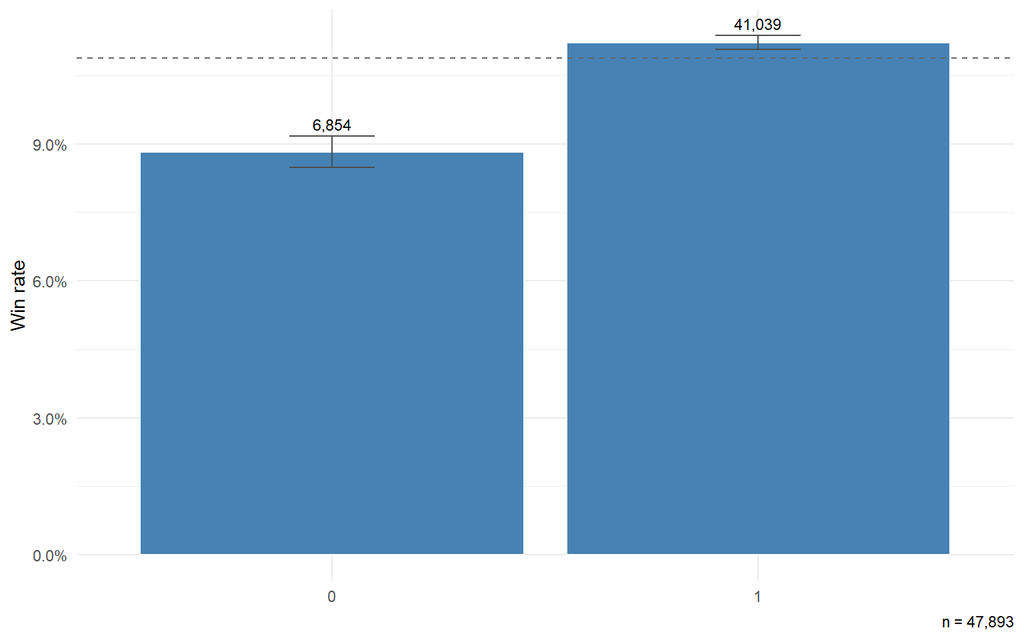

Figure 13: Win rate by has_wins

### 3.6.7 Prior finishing positions

The three prior-finish lags are screened as one feature but plotted separately, most-recent first. Each is an integer in {0, 1, 2, 3, 4}, where 0 means “no prior run, or finished worse than 4th”.

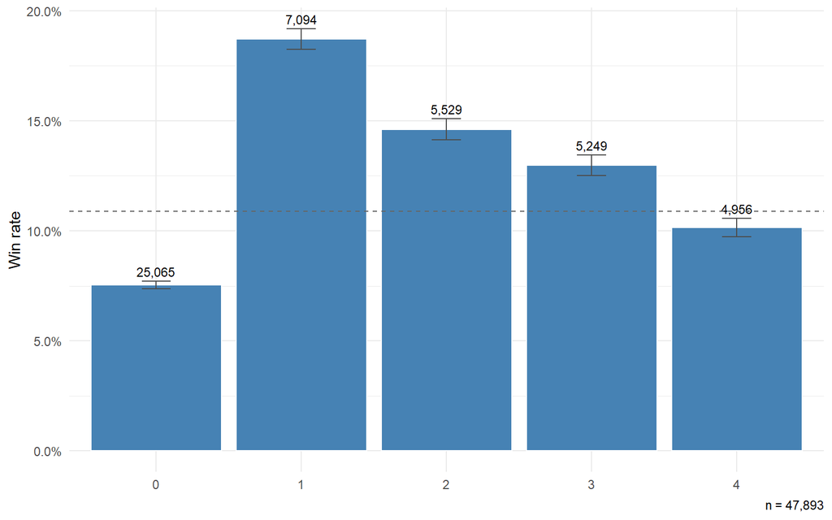

Figure 14: Win rate by position1 (most recent prior finish).

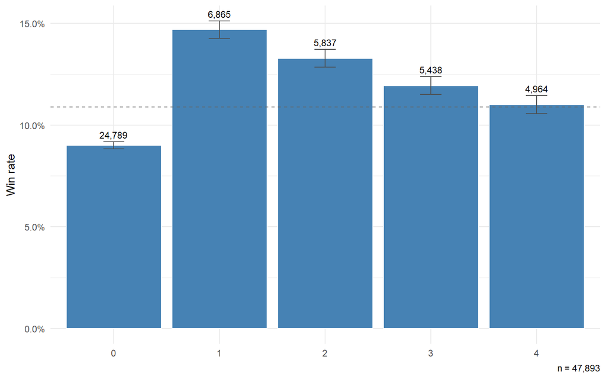

Figure 15: Win rate by position2 (second-most-recent prior finish).

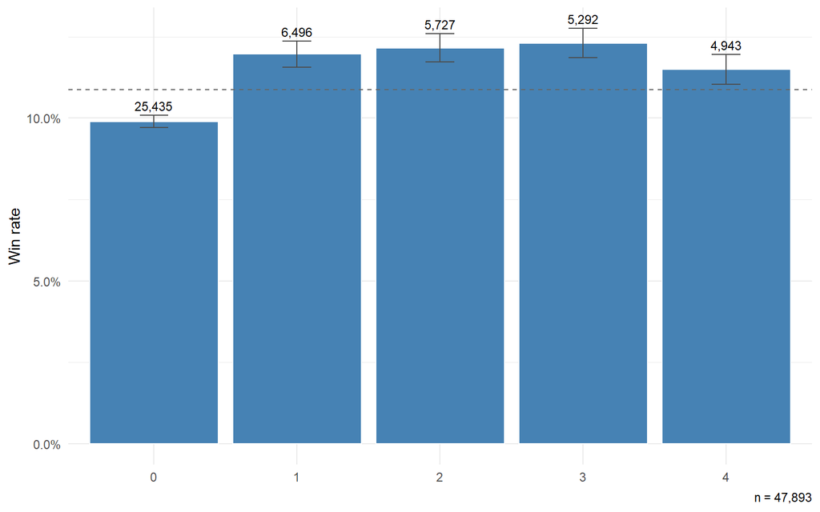

Figure 16: Win rate by position3 (third-most-recent prior finish).

# 4 Extended win model

This section fits the conditional-logit win model on the extended feature set and evaluates it out-of-sample. The recipe parallels paper 1 exactly — fit the full specification on the training races, then drop every term with $p > 0.05$ and refit to a reduced headline model — but two things change. The predictor set is wider (the retained paper-2 features from Section 3), and the prior-finish lags now use the **zero-plus-slope** encoding: for each lag $N$, a zero indicator `pos_lagN_zero` (no prior run, or finished worse than 4th) plus the graded raw position `pos_lagN_nonzero` (1–4). The race scope, train/test split (70/30 chronological, cutoff 2012-12-30) and diagnostic suite are unchanged from paper 1, so the two models are directly comparable. Fitting is training-only; every evaluation below is on the held-out test races.

## 4.1 Full and reduced fit

The full specification has 19 terms. The reduced model drops any term with $p > 0.05$ and refits (iterating the elimination once); on these data only the lag-3 position pair falls away, leaving 17 coefficients.

Table 8: Reduced extended win model (AW training fit), zero-plus-slope position encoding. Coefficients grouped by block; significance **p<0.001,** p<0.01, p<0.05. The position lags enter as the semi-parsimonious zero-plus-slope pair per lag (zero indicator + graded 1–4 value), not as paper 1’s factor grid.

| Block | Term | Estimate | Std. error | z | p-value | Sig |
| --- | --- | --- | --- | --- | --- | --- |
| 1. Position encoding (zero-plus-slope) | pos_lag1_zero | -0.8239 | 0.0525 | -15.69 | 0.00e+00 | *** |
| 1. Position encoding (zero-plus-slope) | pos_lag1_nonzero | -0.1494 | 0.0182 | -8.19 | 0.00e+00 | *** |
| 1. Position encoding (zero-plus-slope) | pos_lag2_zero | -0.3258 | 0.0541 | -6.02 | 0.00e+00 | *** |
| 1. Position encoding (zero-plus-slope) | pos_lag2_nonzero | -0.0495 | 0.0190 | -2.61 | 9.04e-03 | ** |
| 2. Form / history (Owen) | daysLTO (log) | -0.1277 | 0.0179 | -7.13 | 0.00e+00 | *** |
| 2. Form / history (Owen) | trainerSR | 3.3172 | 0.4182 | 7.93 | 0.00e+00 | *** |
| 2. Form / history (Owen) | sireSR | 1.8271 | 0.4217 | 4.33 | 1.47e-05 | *** |
| 3. Horse characteristics (Owen) | age_diff | -0.0915 | 0.0140 | -6.54 | 0.00e+00 | *** |
| 3. Horse characteristics (Owen) | entire | 0.4411 | 0.0574 | 7.69 | 0.00e+00 | *** |
| 3. Horse characteristics (Owen) | gelding | 0.2433 | 0.0453 | 5.37 | 1.00e-07 | *** |
| 3. Horse characteristics (Owen) | cheekpieces | -0.2690 | 0.0614 | -4.38 | 1.17e-05 | *** |
| 4. New features (paper 2) | jockeySR | 4.0923 | 0.4826 | 8.48 | 0.00e+00 | *** |
| 4. New features (paper 2) | rel_weight | -0.0309 | 0.0047 | -6.60 | 0.00e+00 | *** |
| 4. New features (paper 2) | or_relative | 0.0783 | 0.0043 | 18.36 | 0.00e+00 | *** |
| 4. New features (paper 2) | or_missing | -0.3845 | 0.0863 | -4.46 | 8.30e-06 | *** |
| 4. New features (paper 2) | trainer_aw_premium | 1.7298 | 0.4419 | 3.91 | 9.06e-05 | *** |
| 4. New features (paper 2) | has_wins | 0.1209 | 0.0559 | 2.16 | 3.04e-02 | * |

**Terms dropped from the full model** ($p > 0.05$, removed before the reduced refit): pos_lag3_zero, pos_lag3_nonzero. Only the third prior-finish lag falls out — the same lag paper 1 drops (`position3`) — confirming that the third-back race adds nothing once the two most recent are in the model.

Table 9: Full vs reduced extended model: training-set fit statistics. McFadden R² is the pseudo-R² 1 − logLik / null logLik.

| Model | logLik | Null logLik | McFadden R² | Races | Runner-rows |
| --- | --- | --- | --- | --- | --- |
| full | -10113.0 | -10995.3 | 0.0802 | 5065 | 46399 |
| reduced | -10117.6 | -10995.3 | 0.0798 | 5065 | 46399 |

Section 2 reported the feature set as essentially complete, but the conditional logit is fitted complete-case at the race level — a race is dropped whole if any runner is missing any modelling column — so the fit rests on 5,065 of the 5,209 training races, 144 dropped (2.8%). The losses sit almost entirely in the pre-race strike rates, which are undefined under the strict-before temporal rule when a runner’s jockey, sire or trainer has no qualifying prior run: a missing `jockeySR` touches 88 races, `sireSR` 35, `trainerSR` 23, and `days_LTO_log` just 2 (debut runners). The sets overlap, so these counts do not sum to 144. The test set is filtered the same way, which is why paper 1 and paper 2a evaluate on slightly different race universes — a point we return to when comparing backtests in Section 6.

Every retained coefficient carries the sign its feature predicts. The zero-plus-slope position terms are all negative: a missing or worse-than-4th recent run (`pos_lag1_zero` = -0.824) is a sizeable penalty, and within graded finishes a larger position number — a worse placing — lowers the win odds (`pos_lag1_nonzero` = -0.149). The effect decays across lags exactly as the encoding intends: lag 1 dominates, lag 2 is weaker, lag 3 is gone. `age_diff` (-0.091) and `days_LTO_log` (-0.128) are negative as in paper 1 (distance from peak age, and rust — the loss of sharpness from time away from racing, captured by `days_LTO_log`). The three strike rates are strongly positive, and the new features behave: `rel_weight` (-0.031) is negative — carrying more than the field’s mean weight lowers the win probability, the handicap signal paper 1 flagged as missing — and `or_relative` (+0.078) is the single most significant term in the model.

## 4.2 Comparison with Owen and paper 1

Read against Owen’s Table 3 and paper 1’s AW reduced fit, the carried- over Owen features land where expected and the new features reshape a couple of them.

- **Age, sex, tack.** `age_diff` is negative (Owen −0.152; ours -0.091), `entire` (+0.441) and `gelding` (+0.243) positive, `cheekpieces` (-0.269) negative — the same pattern as Owen and paper 1. As in paper 1, `gelding` is roughly half Owen’s +0.548, the AW population being gelding-heavy so the contrast with the reference is compressed.
- **Strike rates attenuate — the main surprise.** Paper 1’s AW reduced fit put `trainerSR` at +5.09 and `sireSR` at +2.36 (proportion scale); here they fall to +3.317 and +1.827. The cause is the new `jockeySR` (+4.092, itself larger than `trainerSR`) and `or_relative`, which are correlated with trainer/sire quality and absorb signal that paper 1 had no choice but to load onto the two strike rates. Divided by 100 for Owen’s apparent percent scale, AW `trainerSR` now reads ~0.033 — below Owen’s 0.051, where paper 1 matched him almost exactly.
- **New features earn their place.** `or_relative` is the dominant predictor (the most statistically significant term in the table) — unsurprising, since the official rating is the handicapper’s direct estimate of relative ability, and the starting price paper 1 lost to is built on the same information. Its companion `or_missing` (-0.385) is negative: unrated horses, controlling for everything else, win less. `rel_weight`, `jockeySR` and `trainer_aw_premium` (+1.730) are all significant; `has_wins` (+0.121) survives only marginally.

## 4.3 Out-of-sample evaluation: calibration

As in paper 1 we score the reduced model on the **test races** — out-of-sample forecasts, not in-sample fits — and build market-implied probabilities from the over-round-adjusted industry starting price (SP), renormalised per race. The calibration plot bins predicted (or implied) win probability in 5-point intervals over $[0, 0.50]$; perfect calibration sits on $y = x$.

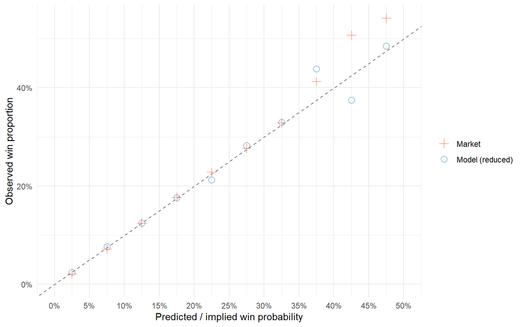

Figure 17: Calibration on the AW test set (Owen Figure 7 equivalent): observed win proportion vs predicted / implied win probability, 5-point bins over [0, 0.50]. Circles = extended reduced model (out-of-sample); plus signs = market. Dashed line y = x is perfect calibration.

## 4.4 Out-of-sample evaluation: P1 and P2 scoring rules

The two scoring rules follow Owen’s Figure 8, evaluated out-of-sample. For each threshold $t$, over runner-rows whose probability exceeds $t$: $P_1$ is the geometric mean of probability assigned to actual winners, and $P_2$ the geometric mean of the per-row Bernoulli likelihood (a proper scoring rule that also penalises high probability on losers). At any given threshold, a higher $P_1$ or $P_2$ means the model (or the market) is doing better at that threshold — though $P_2$ itself trends down as the threshold rises, since it is then conditioned on a smaller, more selective set of bets.

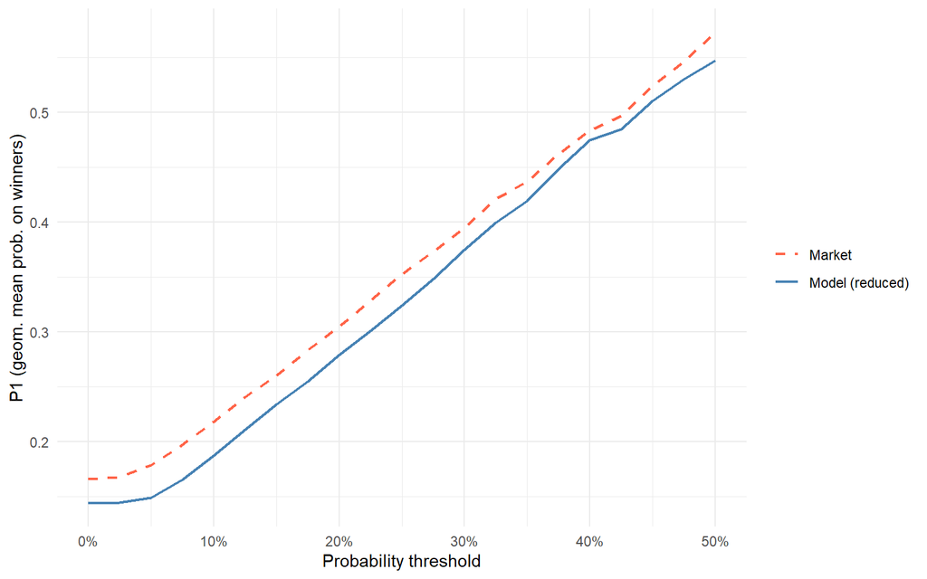

Figure 18: P1 vs probability threshold (Owen Figure 8a equivalent), AW test set. Higher = more probability mass on eventual winners.

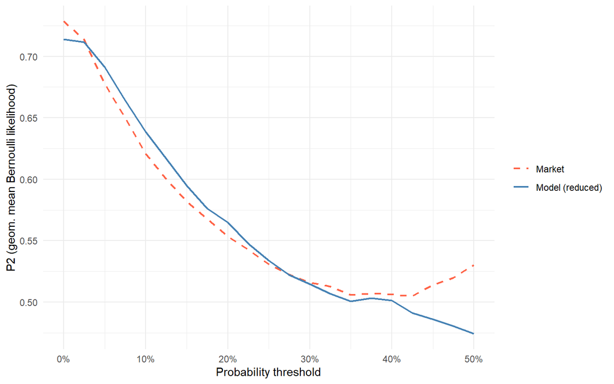

Figure 19: P2 vs probability threshold (Owen Figure 8b equivalent), AW test set. Proper scoring rule: calibration plus discrimination.

## 4.5 Betting backtest

We apply Owen’s exact bet-selection rule to the AW test set: back a horse when the model gives it more than a 15% chance of winning ($\hat{P} > 0.15$) and the model’s probability is at least 1.3 times the market-implied probability (ratio $> 1.3$) — that is, the model must be both confident in absolute terms and clearly more bullish than the market. The rule can qualify more than one horse in a race; Owen does not specify whether he backs one qualifier or all, and here we back all (the multi-bet rule). We then sweep the ratio threshold from 0.9 to 2.0 with the model-probability filter held at 0.13 and a 90% bootstrap CI (race-level resampling, $B = 2000$, seed 42) — the same procedure paper 1 ran, so the ROI is directly comparable to paper 1’s headline **−28.2%**.

Table 10: Extended reduced model: betting backtest on the AW test races at Owen’s exact thresholds.

| Prob threshold | Ratio threshold | Bets | Wins | Gross return | Profit | ROI |
| --- | --- | --- | --- | --- | --- | --- |
| 0.15 | 1.3 | 1596 | 177 | 1180.63 | -415.37 | -26.0% |

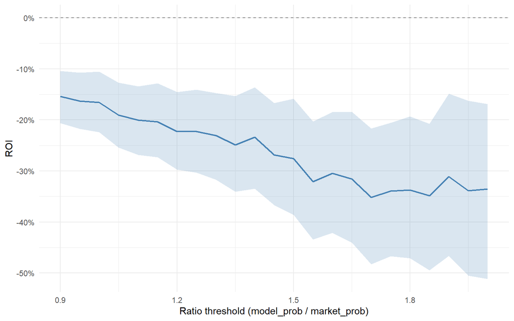

Figure 20: ROI vs ratio threshold on the AW test set (extended model), 90% bootstrap CI shaded. Model-probability filter held at 0.13; dashed line at zero marks break-even.

Table 11: ROI sweep over ratio thresholds with 90% bootstrap CIs (B = 2000, race-level resampling, seed 42).

| Ratio threshold | Bets | Wins | ROI | 90% CI low | 90% CI high |
| --- | --- | --- | --- | --- | --- |
| 0.90 | 3990 | 627 | -15.4% | -20.6% | -10.4% |
| 0.95 | 3701 | 549 | -16.3% | -21.7% | -10.7% |
| 1.00 | 3419 | 487 | -16.6% | -22.4% | -10.5% |
| 1.05 | 3163 | 416 | -19.1% | -25.4% | -12.7% |
| 1.10 | 2913 | 365 | -20.0% | -26.8% | -13.4% |
| 1.15 | 2684 | 321 | -20.4% | -27.3% | -12.8% |
| 1.20 | 2484 | 279 | -22.2% | -29.7% | -14.5% |
| 1.25 | 2312 | 249 | -22.3% | -30.4% | -14.1% |
| 1.30 | 2140 | 220 | -23.1% | -31.7% | -14.7% |
| 1.35 | 1982 | 193 | -24.9% | -34.0% | -15.4% |
| 1.40 | 1805 | 173 | -23.4% | -33.5% | -13.6% |
| 1.45 | 1660 | 148 | -26.9% | -36.7% | -16.7% |
| 1.50 | 1522 | 130 | -27.6% | -38.6% | -15.9% |
| 1.55 | 1395 | 107 | -32.1% | -43.4% | -20.3% |
| 1.60 | 1282 | 99 | -30.4% | -42.1% | -18.4% |
| 1.65 | 1186 | 87 | -31.6% | -44.0% | -18.4% |
| 1.70 | 1080 | 73 | -35.2% | -48.3% | -21.7% |
| 1.75 | 1008 | 66 | -33.9% | -46.7% | -20.6% |
| 1.80 | 940 | 61 | -33.7% | -47.1% | -19.3% |
| 1.85 | 878 | 54 | -34.9% | -49.4% | -20.8% |
| 1.90 | 826 | 53 | -31.1% | -46.6% | -14.9% |
| 1.95 | 768 | 45 | -33.9% | -50.5% | -16.2% |
| 2.00 | 706 | 41 | -33.6% | -51.2% | -16.9% |

## 4.6 Does the extended feature set improve on paper 1?

The extended reduced model reaches a McFadden pseudo-R² of 0.08 on the training races, comfortably above the paper-1 specification — most of the lift coming from `or_relative`, the handicapper’s rating, together with `jockeySR` and `rel_weight`, none of which Owen or paper 1 used. The naive backtest ROI improves from paper 1’s −28.2% to **-26.0%** — directionally better, but still firmly negative, and the ratio sweep’s 90% CI sits below zero across the threshold range.

The framing from paper 1 holds. On calibration and the P1/P2 scoring rules the model has closed some of the gap to the market but has not overtaken it: adding `or_relative` pulls the feature set onto part of the information the starting price already prices, which is exactly why discrimination improves, yet the SP still aggregates more — weight-by- draw interactions, going suitability — than even the widened feature set captures. The extended *win* model is a better forecaster than paper 1’s; whether *race-level interactions* narrow the remaining gap is the question for Section 5. (Whether changing the objective from the win to the full finishing order helps is the subject of the companion paper 2b.)

# 5 Mixed race-level interactions

The features so far are all horse-level. Race-level features — going, distance, course — cannot enter the conditional logit directly: they are constant within a race and cancel in the softmax. They enter only as **interactions** with horse-level features, whose products vary across runners within a race (the mixed discrete-choice mechanism derived in Section 7). This section tests two such interactions on top of the extended win model from Section 4, which is the baseline throughout.

## 5.1 Two interactions

**Weight × distance** (`rel_weight_x_dist = rel_weight × distance_furlongs`). `rel_weight` is horse-level, `distance_furlongs` race-level; their product varies across runners. The motivation is Benter (1994): the burden of extra weight should compound over longer trips, so a horse carrying weight above the field mean ought to be penalised more in a staying race than a sprint.

**Draw × course.** Draw bias on All-Weather is known to depend on the track — Kempton, Lingfield, Southwell and Wolverhampton have different configurations, bend tightness and run-ins. `stall_normalised` had almost no standalone signal (Section 3), but that pooled estimate could be hiding course-specific effects that cancel. We split it into four course-masked columns (`stall_normalised` where the race is at that course, else 0), one coefficient per course.

Table 12: Interaction features on the training split.

| Quantity | Value |
| --- | --- |
| Distance range (furlongs) | 5 – 16.5 |
| rel_weight_x_dist SD | 43.1 |
| Runners with a Kempton draw term | 14,540 |
| Runners with a Lingfield draw term | 12,524 |
| Runners with a Southwell draw term | 6,734 |
| Runners with a Wolverhampton draw term | 14,088 |

## 5.2 Likelihood-ratio tests

Four models, all fitted on one common training sample so the tests are nested and valid: **W** (extended win baseline), **W+weight**, **W+draw**, and **W+both** (the **W** prefix denoting the extended win baseline of Section 4, and the suffixes its two candidate interactions). One training race with draw-less runners is dropped from all four, so the baseline here is the extended win model refitted on that shared 5,064-race sample (it differs from Section 4’s fit by that single race; the base coefficients are unchanged to three decimals).

Table 13: Likelihood-ratio tests among the four interaction models, all fitted on the extended win model.

| Test | Comparison | LR stat | df | p-value | Verdict |
| --- | --- | --- | --- | --- | --- |
| W+weight vs W | Weight×distance vs baseline | 0.87 | 1 | 0.35000 | no improvement |
| W+draw vs W | Draw×course vs baseline | 16.26 | 4 | 0.00269 | adds signal |
| W+both vs W | Both vs baseline | 17.08 | 5 | 0.00435 | adds signal |
| W+both vs W+weight | Draw×course \| weight×distance | 16.21 | 4 | 0.00275 | adds signal |
| W+both vs W+draw | Weight×distance \| draw×course | 0.82 | 1 | 0.36400 | no improvement |

The verdict is clean. **Draw×course adds signal** (W+draw vs W: $p =$ 0.0027; and it survives conditional on weight). **Weight×distance does not** — it is indistinguishable from zero both on its own (W+weight vs W: $p =$ 0.35) and added to draw (W+both vs W+draw: $p =$ 0.36). The most parsimonious model not rejected at $p < 0.05$ is therefore **W+draw** (extended win + draw×course). The likelihood-ratio statistics are modest; a fuller use of the data — the exploded ranking likelihood of paper 2b, which triples the number of choice problems per race — may estimate the same interaction more sharply, a question we leave to that paper.

The draw×course term enters as a **block**: the four course-masked columns are admitted together on the W+draw vs W likelihood-ratio test above, which establishes that course-specific draw bias carries signal the pooled term could not. Admitting the block is one question; which individual course slopes to *retain* is another, and we settle it with the same per-term Wald rule paper 1 and Owen use, and that reduces the position-lag block in Section 4 — a course slope individually non-significant at $p < 0.05$ is dropped. Of the four slopes in the fitted block, Kempton (+0.231, $p =$ 0.0086) and Southwell (+0.271, $p =$ 0.025) clear the threshold; Lingfield (+0.088, $p =$ 0.35) and Wolverhampton (-0.160, $p =$ 0.065) do not, and are dropped.

Table 14: Within-block reduction of the draw×course term: two sequential one-degree-of-freedom likelihood-ratio tests, each dropping one individually non-significant course slope from the model above it, all on the common training sample. Neither drop is rejected at p < 0.05, so the final model retains only Kempton and Southwell.

| Drop | LR stat | df | p-value | Verdict |
| --- | --- | --- | --- | --- |
| Lingfield | 0.89 | 1 | 0.3460 | drop term |
| Wolverhampton | 3.40 | 1 | 0.0653 | drop term |

The reduction is confirmed by the two sequential reduction tests in Table 14 — each a one-degree-of-freedom likelihood-ratio test, which drops a single coefficient and checks whether the simpler model loses significant fit. Dropping Lingfield from the four-course block costs nothing ($p =$ 0.35), and dropping Wolverhampton from the remaining three is likewise not rejected at the 5% level ($p =$ 0.065, though it is the closer call). The same inclusion rule — individual Wald $p < 0.05$ — was applied identically to both courses: this is a mechanical rule decision, not a judgement call, even though Wolverhampton’s $p$ sits close to the line. The **final paper-2a model** is therefore the extended win model plus two course-specific draw slopes — Kempton and Southwell — 19 coefficients in all.

## 5.3 The final model vs the baseline

Table 15: Base (17-term) coefficients: extended win baseline (W) vs the final model. The draw terms leave the base estimates essentially unchanged.

| Term | W est. | Final est. |
| --- | --- | --- |
| pos_lag1_zero | -0.8242 | -0.8248 |
| pos_lag1_nonzero | -0.1494 | -0.1496 |
| pos_lag2_zero | -0.3239 | -0.3230 |
| pos_lag2_nonzero | -0.0489 | -0.0487 |
| age_diff | -0.0917 | -0.0912 |
| days_LTO_log | -0.1278 | -0.1279 |
| trainerSR | 3.3166 | 3.3252 |
| sireSR | 1.8291 | 1.8265 |
| jockeySR | 4.0946 | 4.0869 |
| entire | 0.4411 | 0.4410 |
| gelding | 0.2435 | 0.2428 |
| cheekpieces | -0.2690 | -0.2692 |
| rel_weight | -0.0310 | -0.0310 |
| or_relative | 0.0783 | 0.0782 |
| or_missing | -0.3846 | -0.3830 |
| trainer_aw_premium | 1.7303 | 1.7093 |
| has_wins | 0.1213 | 0.1225 |

Table 16: Draw×course coefficients in the full four-course block (the selection-stage fit). The slope is on stall_normalised (draw position / field size), per course. Kempton and Southwell are individually significant and retained; Lingfield and Wolverhampton are non-significant at p < 0.05 and dropped, leaving the two-course final model.

| Course | Estimate | Std. error | z | p-value | Sig | Retained |
| --- | --- | --- | --- | --- | --- | --- |
| Kempton | 0.2314 | 0.0881 | 2.63 | 0.00858 | ** | yes |
| Lingfield | 0.0879 | 0.0932 | 0.94 | 0.34600 | (ns) | dropped |
| Southwell | 0.2706 | 0.1205 | 2.24 | 0.02480 | * | yes |
| Wolverhampton | -0.1604 | 0.0871 | -1.84 | 0.06550 | (ns) | dropped |

Adding the interaction barely moves the base coefficients — draw is roughly orthogonal to form and rating — so the final model inherits the whole extended-feature story and adds the draw effect on top.

**Which courses carry draw bias, and the sign flips that hid it.** Within the fitted block the four course slopes disagree on both direction and strength. Kempton (+0.231, $p =$ 0.0086) and Southwell (+0.271, $p =$ 0.025) show a clear, significant advantage to **higher** draws and are the two courses the final model keeps. Wolverhampton (-0.160, $p =$ 0.065) leans the other way, towards **lower** draws, but only marginally; Lingfield (+0.088, $p =$ 0.35) shows essentially none. Under the win objective — with only the win indicator to estimate from — neither clears the 5% bar, so both drop out. The substantive finding survives the reduction: the per-course effects point in *opposite directions*, so a single pooled draw coefficient averages them to almost nothing, which is exactly why `stall_normalised` looked dead in the univariate screen. A feature that appears useless in isolation carries real, track-specific signal once the race-level structure is respected through the interaction — the clearest vindication in this paper of the mixed-logit construction.

**Weight × distance: Benter’s compounding not detected.** The weight×distance term is statistically indistinguishable from zero on this data. Benter’s intuition — that weight bites harder over a longer trip — may simply be too weak to register in Class 2–5 AW handicaps, where the handicapper has already set weights to equalise the field and the distance range is moderate, or it may be that `rel_weight` (a within-race deviation) already absorbs the level effect with little left for a distance modulation. Either way, it does not earn a place in the model.

## 5.4 Out-of-sample diagnostics

We evaluate the final model exactly as before: win probabilities on the test races against the over-round-adjusted market, the same suite as Section 4.

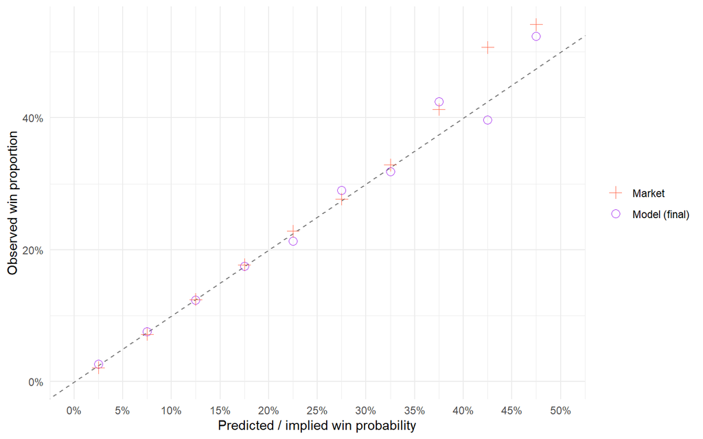

Figure 21: Calibration on the AW test set, final model (Owen Figure 7 equivalent): observed win proportion vs predicted / implied win probability, 5-point bins over [0, 0.50]. Circles = final model (out-of-sample); plus signs = market; dashed line y = x.

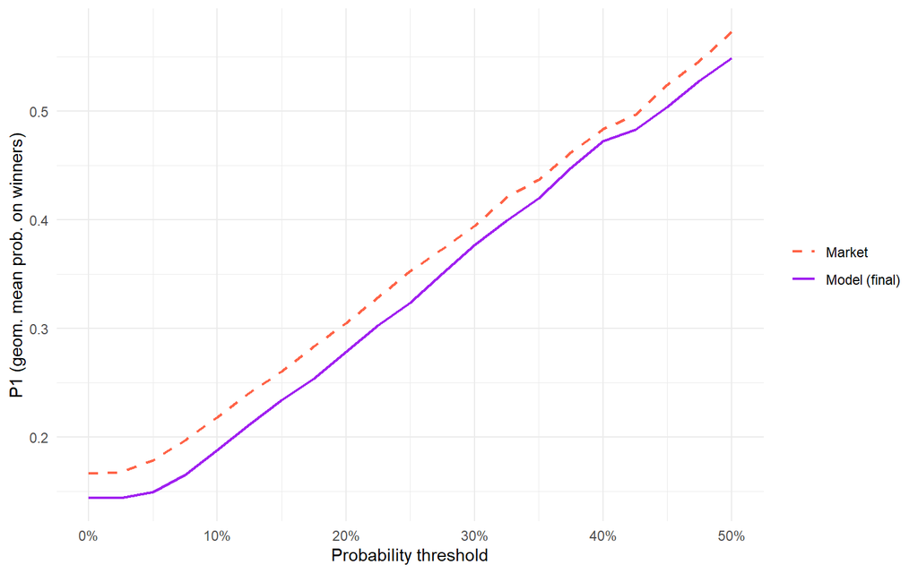

Figure 22: P1 vs probability threshold, final model (Owen Figure 8a equivalent), AW test set.

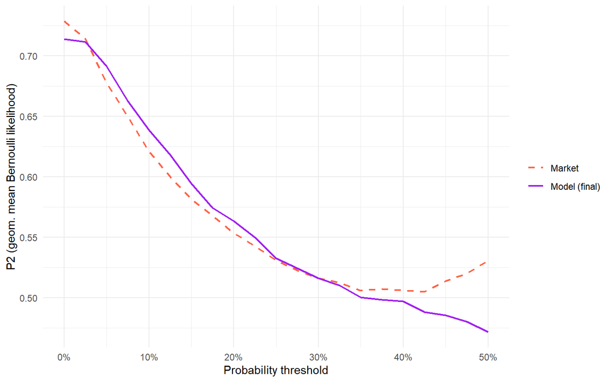

Figure 23: P2 vs probability threshold, final model (Owen Figure 8b equivalent), AW test set.

Table 17: Final model: betting backtest on the AW test races at Owen’s exact thresholds.

| Prob threshold | Ratio threshold | Bets | Wins | Gross return | Profit | ROI |
| --- | --- | --- | --- | --- | --- | --- |
| 0.15 | 1.3 | 1598 | 178 | 1191.38 | -406.62 | -25.4% |

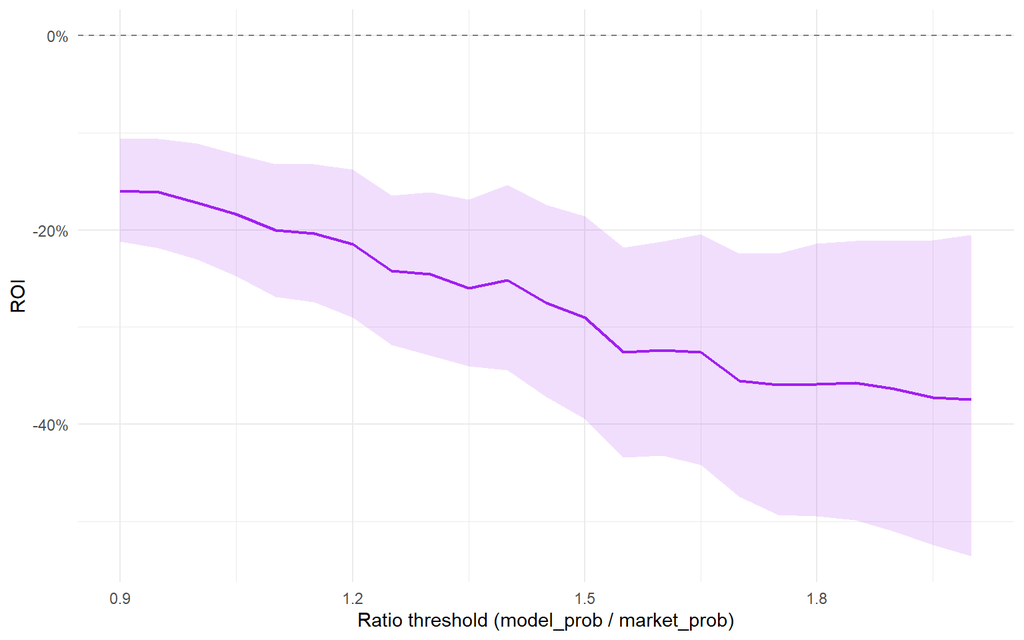

Figure 24: ROI vs ratio threshold on the AW test set (final model), 90% bootstrap CI shaded. Model-probability filter held at 0.13; dashed line at zero marks break-even.

## 5.5 Do the interactions add anything?

The final model’s naive backtest ROI is **-25.4%**, against the extended win model’s -26.0% and paper 1’s −28.2%. Restricting to one bet per race — among the qualifiers, the horse with the highest model win probability — gives -25.9% on 1,305 bets, marginally worse than backing all qualifiers. We nonetheless adopt this single-bet rule as the primary, more realistic strategy from this paper onwards: on the win market it makes no material difference, but it matters for the place and each-way markets examined in paper 2b. The point estimates improve at every step; the extended feature set — chiefly the official rating — accounts for most of that gain, with the course-specific draw effect adding a smaller further increment. But the improvement is small relative to its sampling noise: a paired race-level bootstrap of the ROI *differences* (reported in Section 6) cannot separate any of these contrasts from zero. The direction is at least intuitive in the market-efficiency frame: draw bias is a genuine, track-specific edge a 13-feature win model could not see, and the starting price — built partly on punters who *do* know each course’s draw — was pricing it while the model was not.

And yet the result is still a clear loss. The ratio-sweep CI narrows but does not cross zero: the market still prices the field more accurately than the model overall. Paper 2a’s arc is a *directional* narrowing of the gap to the starting price — richer features and the draw interaction together move the point ROI from −28.2% to -25.4%, though a paired bootstrap cannot rule out that the true gap is unchanged. What remains uncaptured is the part of the market’s edge that lives in information our pre-race feature set still does not contain — late money, going on the day — together with a genuine structural limit of the model itself: a linear-predictor conditional logit cannot represent non-linearities or feature interactions beyond those we hand-build, which is the subject of paper 3. This paper also deliberately scopes to the win outcome rather than the full finishing order; using the finishing order is the subject of the companion paper 2b — a change of objective, not a shortfall of this one.

# 6 Discussion

## 6.1 Model progression

Paper 2a makes two additions to paper 1’s model, and each earns its place. Table 18 lines up the three fits on a common footing: the McFadden pseudo-$R^2$ on the training races, and the naive betting ROI and race count on the held-out test set.

Table 18: Paper-2a model progression: McFadden R² on training, naive ROI and test-race count on the held-out set. The three models evaluate on slightly different test universes — paper 1 retains races that paper 2a’s extra features drop to NA (Section 4) — so the ROIs are not struck on an identical race set; the paired bootstrap below removes that confound by intersecting each pair’s common races.

| Model | McFadden R² | Naive ROI | Test races |
| --- | --- | --- | --- |
| Paper 1 (replication) | 0.0532 | -28.2% | 2,224 |
| Extended win model | 0.0798 | -26.0% | 2,193 |
| Final (extended win + draw×course) | 0.0804 | -25.4% | 2,193 |

The picture is one of modest, point-estimate improvement. The extended feature set lifts discrimination above paper 1, the single largest contributor being `or_relative` — the handicapper’s own assessment of ability, the strongest new predictor in the model — and accounts for most of the backtest gain as well, with the course-specific draw effect adding a smaller further increment. The naive ROI climbs at each step, from −28.2% in paper 1 to -25.4% in the final model. Whether that climb is real or sampling noise is the question the next table settles.

Because the three models are scored on overlapping but non-identical test races, and because each model’s ROI is itself a noisy statistic, the marginal bootstrap intervals of Section 5 cannot tell us whether the *differences* between models are real. Table 19 answers that directly: for each pair it restricts to the common races, resamples races (paired, so both models see the same resample), and reports the 90% interval of the ROI difference.

Table 19: Paired race-level bootstrap of the ROI difference between models (B = 2000, seed 42), each restricted to the pair’s common test races. A 90% interval spanning zero means the two models’ ROIs are not statistically distinguishable on these data.

| Contrast | ROI diff. | 90% CI | Common races |
| --- | --- | --- | --- |
| Final − Paper 1 | 2.8% | [-6.4%, 12.2%] | 2,193 |
| Final − Extended win | 0.6% | [-2.8%, 4.2%] | 2,193 |
| Extended win − Paper 1 | 2.2% | [-6.9%, 11.5%] | 2,193 |

The verdict is sobering. Every point difference is positive — the ordering paper 1 < extended < final holds — but every 90% interval spans zero. The narrowing of the gap to the market is **directionally consistent but not statistically distinguishable**: on this test set we cannot reject the hypothesis that the extended features and the draw×course interaction leave betting ROI unchanged. The improvement is real in the coefficients and the McFadden $R^2$, where the training sample is large; it is not resolvable in the much noisier, smaller-sample betting return. We report the point gains plainly and decline to call them established.

## 6.2 Why the market still wins

For all that, the final model still loses. Its naive ROI is -25.4%, and the ratio-threshold sweep in Section 5 has a 90% bootstrap interval that does not cross zero at any threshold. The reading is the one paper 1 reached, only on a narrower margin: the starting price aggregates information our pre-race feature set cannot observe. `or_relative` encodes the handicapper’s *historical* assessment of a horse, but not its current readiness — paddock condition, work on the morning, stable confidence — nor the late market moves of informed money that the SP absorbs in the minutes before the off. The favourite–longshot bias documented in paper 1 persists here, and a model built only on form, ratings and draw cannot price the part of the field’s chances that lives in same-day, private information.

A second qualification concerns the benchmark. The ROI is measured at the **industry starting price**, which carries a substantial bookmaker over-round — about 16.1% on these test races — and is therefore the harshest price a bettor could take. We remove that over-round only where we compare the model to the market’s *probabilities* (the calibration plot and the P1/P2 rules renormalise 1/SP to sum to one); it is necessarily kept in the ROI, because a winning bet returns the actual SP, margin and all. The same selections struck on a betting exchange — where Betfair SP charges only commission, of order 2–5%, rather than that margin — would return materially more, though whether enough to reach break-even cannot be settled without exchange prices, which this dataset does not carry. This is the benchmark that matters for the live-trading direction noted under limitations below.

## 6.3 Limitations

- **No live-data test.** The model is fitted and evaluated on the same 2006–2015 window as paper 1; nothing here tests it on current racing, and the AW programme has changed since (new tracks, fixture inflation).
- **Industry-SP benchmark.** Profitability is evaluated at the bookmaker starting price, with its full over-round; a betting exchange (Betfair SP, commission only) is a more favourable — and, for the live-trading direction, more relevant — benchmark. The Smartform data carries only industry SP (the morning forecast price and Tote dividends aside), so a Betfair-SP backtest is left to future work.
- **`or_relative` missing-not-at-random.** The zero-imputation with a missing indicator is defensible, but unrated horses remain a distinct population rather than average ones; the fitted `or_missing` coefficient is negative and significant (-0.383, $p < 0.001$), confirming that they underperform even the imputed zero and that the indicator is carrying a real effect rather than a nuisance.

## 6.4 Where the series goes next

Papers 2b and 3 take the two remaining levers: paper 2b changes the objective from win prediction to ranking, and paper 3 changes the model class from the conditional-logit linear predictor to a tree-based ensemble.

# Acknowledgments

I have been interested in modelling horse racing since first acquiring the Smartform database more than a decade ago. The project has been picked up and put down many times, the obstacle almost always being the gap between an idea and a running implementation. What is different now is that working alongside Claude Code (Anthropic’s coding agent), with web-based Claude as a research companion, has compressed that gap dramatically. I am grateful to my brother, Michael Gillen, for the suggestion to build the model on All-Weather races — the foundation of the scope choices set out in Section 2. The design choices — dataset, scope, model, comparison, editorial line — are mine. The implementation, the bulk of the draft prose, and a great deal of the verification were Claude Code’s, under my direction; every output was reviewed and edited before it reached the paper. I do not yet know what general lessons this experiment points to about the value of human–AI collaboration in applied statistics. That uncertainty is part of why I am doing the work, and these papers are partly a record of that experiment.

# References

Benter, William. 1994. *Computer-Based Horse Race Handicapping and Wagering Systems: A Report*. 183–98.

Bolton, Ruth N., and Randall G. Chapman. 1986. “Searching for Positive Returns at the Track: A Multinomial Logit Model for Handicapping Horse Races.” *Management Science* 32 (8): 1040–60.

Juola, Mikko. 2018. “Feasibility of Building a Profitable Data-Driven Betting System on Horse Races.” Master’s thesis, Aalto University, School of Science. https://aaltodoc.aalto.fi/items/32f909ee-844d-40d0-a1d8-accbaaeb5951.

Owen, Alun. 2019. “Statistical Models of Horse Racing Outcomes Using R.” *MathSport International 2019 Conference Proceedings* (Athens, Greece).

## 7 Appendix: Derivations

This appendix sets out the mixed discrete-choice mechanism by which race-level features enter the model through interactions (Section 5). It builds on the conditional logit derived in paper 1’s appendix, whose notation we reuse: race $i$ is the chooser, horse $j$ the alternative, and the linear predictor for horse $j$ in race $i$ is $z_{ij} = \sum_{l} \beta_l x_{ilj}$ over alternative-specific features $x_{ilj}$, with win probabilities given by the softmax $p_{ij} = e^{z_{ij}} / \sum_m e^{z_{im}}$. (The Plackett–Luce and exploded-logit machinery, which underlies the ranking model of the companion paper 2b, is derived in that paper’s appendix.)

## 7.1 Mixed discrete choice and race-level interactions

Both multinomial and conditional logistic regression are instances of discrete choice models. In practice, a *mixed* or hybrid formulation is sometimes used, in which the linear predictor includes both pure alternative-specific features, pure individual-specific features, and interactions between the two; see Train (2009) for a comprehensive treatment.

In the racing context, recall that individual $i$ is a race and alternative $j$ is a horse. We distinguish two types of feature:

- **Horse-level features** $h_{ijl}$: the $l$-th feature of horse $j$ in race $i$ (e.g. speed figure, weight carried, days since last race). These vary across horses within a race.
- **Race-level features** $r_{il}$: the $l$-th feature of race $i$ (e.g. going, distance, prize money). These are the same for every horse in a given race.

Pure race-level features cannot enter the model directly: since $r_{il}$ does not carry a $j$ index, it is the same for every horse in race $i$ and cancels between numerator and denominator in the softmax, leaving all probabilities unchanged. However, interactions between race-level and horse-level features,
$$x_{ijl} = r_{il} \cdot h_{ijl},$$
do vary across horses within a race and can enter the model. For example, if $r_{i1}$ is an indicator for firm going and $h_{ij1}$ is horse $j$’s historical win rate on firm ground, then $x_{ij1} = r_{i1} \cdot h_{ij1}$ measures how well each horse in the field is suited to today’s conditions.

Paper 2a uses two interactions of this form. The first is **weight × distance**, $x_{ij} = (\text{distance}_i) \cdot (\text{rel\_weight}_{ij})$, where the horse-level weight deviation is scaled by the race distance — Benter (1994)’s hypothesis that the burden of extra weight compounds over a longer trip. The second is **draw × course**, in which the horse-level normalised draw is interacted with a set of course indicators, giving a separate draw slope per course; here the “race-level feature” is the categorical course, and the interaction lets a draw effect that cancels when pooled (because it points in opposite directions at different tracks) emerge per course. Section 5 reports that the draw × course interaction is significant while weight × distance is not.

### References for this appendix

- Train, K. E. (2009). *Discrete Choice Methods with Simulation* (2nd ed.). Cambridge University Press.

## 8 Appendix: Software and reproducibility

The software stack — R, the tidyverse, {mlogit} for the conditional-logit fits, {DBI}/{RMariaDB} for the Smartform database, {renv} for package pinning, and Quarto for typesetting — is the same as paper 1’s, whose appendix B describes it in full, and we do not repeat that here. As there, the whole analysis is a {targets} pipeline: each step in the data → features → model → render chain is a `tar_target()`, intermediate results are cached on disk, and a single `targets::tar_make()` from the project root rebuilds every stale step and re-renders the paper. Fitting is on the training split only; every out-of-sample figure is computed on the held-out test races.

## Footnotes

[^1]: This revision clarifies Owen’s betting rule (multiple horses may qualify per race; we back all) and reports the single-bet win backtest, adopting single-bet as the primary rule from this paper onwards.